# 3. Remove Stop Words, Numbers, Etc.

Luckily, `tidytext` has some built-in libraries of stop words. We’ll use an `anti_join()` to get rid of stop words anc clean our tokens.

```r
# remove stop words
data("stop_words")
tokens_clean <- tokens %>%
  anti_join(stop_words)
```

While we’re at it, we’ll use a regex to clean all numbers.

```r
# remove numbers
nums <- tokens_clean %>% filter(str_detect(word, "^[0-9]")) %>% select(word) %>% unique()

tokens_clean <- tokens_clean %>%
  anti_join(nums, by = "word")
```

I also did a quick pass over `tokens_clean` to look for other meaningless tokens that escaped the stop-word dictionary and the numbers. It’s not surprising that the tokens that made it by were:

- al - from citations (e.g. - et. al)
- figure - looks like I have a lot of figure captions and references in my prospectus
- i.e. - gotta love those parentheticals
- etc…

I’ll store these unique stop words in a vector and perform another `anti_join`, et voila. A tidy, clean list of tokens and counts.

```r
# remove unique stop words that snuck in there
uni_sw <- data.frame(word = c("al","figure","i.e", "l3"))

tokens_clean <- tokens_clean %>%
  anti_join(uni_sw, by = "word")
```

# 4. Make a Word Cloud of the top 50 words

And just like that, an easy word cloud. In fact, this code was so simple and fun that I wrapped it into a [Shiny App](https://richpauloo.shinyapps.io/word_cloud_app).

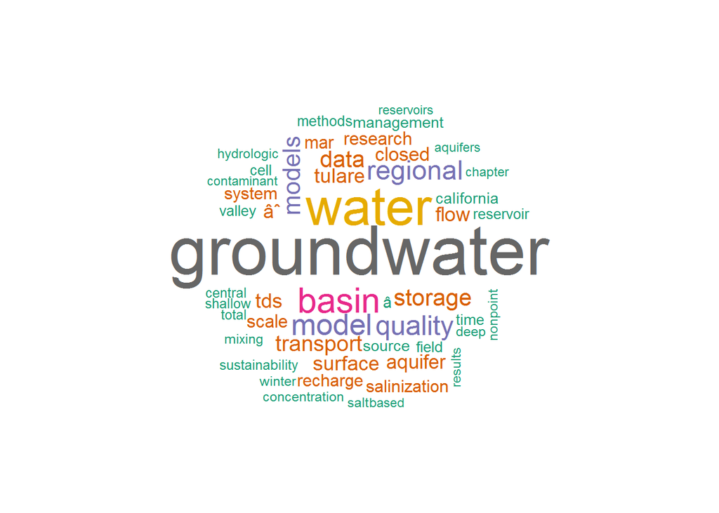

[figure not shown]

```r
# define a nice color palette
pal <- brewer.pal(8,"Dark2")

# plot the 50 most common words
tokens_clean %>%
  with(wordcloud(word, n, random.order = FALSE, max.words = 50, colors=pal))
```

# Data Table

Just for fun, let’s add a searchable data table with the `DT` package.

```r
tokens_clean %>%
  DT::datatable()
```

|  | word | n |
| --- | --- | --- |
| 1 | groundwater | 192 |
| 2 | water | 138 |
| 3 | basin | 84 |
| 4 | model | 69 |
| 5 | quality | 62 |
| 6 | regional | 58 |
| 7 | models | 52 |
| 8 | storage | 48 |
| 9 | data | 46 |
| 10 | transport | 42 |

[output cut: 1679 more lines]

In another post, I’ll dig deeper into NLP, and compare documents to explore how to quantify relationships between documents with *idf*, *tf-idf*, and *cosine similarity*.